# Multidimensional trophic niche revealed by complementary approaches: Gut content, digestive enzymes, fatty acids and stable isotopes in Collembola - Potapov - - Journal of Animal Ecology - Wiley Onlin

[Journal of Animal Ecology](https://besjournals.onlinelibrary.wiley.com/journal/13652656)

[figure not shown]

RESEARCH ARTICLE

Open Access

# Multidimensional trophic niche revealed by complementary approaches: Gut content, digestive enzymes, fatty acids and stable isotopes in Collembola

[Anton M. Potapov](https://besjournals.onlinelibrary.wiley.com/action/doSearch?ContribAuthorStored=Potapov%2C+Anton+M),

[Melanie M. Pollierer](https://besjournals.onlinelibrary.wiley.com/action/doSearch?ContribAuthorStored=Pollierer%2C+Melanie+M),

[Sandrine Salmon](https://besjournals.onlinelibrary.wiley.com/action/doSearch?ContribAuthorStored=Salmon%2C+Sandrine),

[Vladimír Šustr](https://besjournals.onlinelibrary.wiley.com/action/doSearch?ContribAuthorStored=%C5%A0ustr%2C+Vladim%C3%ADr),

[Ting-Wen Chen](https://besjournals.onlinelibrary.wiley.com/action/doSearch?ContribAuthorStored=Chen%2C+Ting-Wen),

First published: 29 April 2021

https://doi.org/10.1111/1365-2656.13511

**Handling Editor:** Natalie Clay

## Abstract

1. Trophic niche differentiation may explain coexistence and shape functional roles of species. In complex natural food webs, however, trophic niche parameters depicted by single and isolated methods may simplify the multidimensional nature of consumer trophic niches, which includes feeding processes such as food choice, ingestion, digestion, assimilation and retention.
2. Here we explore the correlation and complementarity of trophic niche parameters tackled by four complementary methodological approaches, that is, visual gut content, digestive enzyme, fatty acid and stable isotope analyses—each assessing one or few feeding processes, and demonstrate the power of method combination.
3. Focusing on soil ecosystems, where many omnivore species with cryptic feeding habits coexist, we chose Collembola as an example. We compiled 15 key trophic niche parameters for 125 species from 40 studies. We assessed correlations among trophic niche parameters and described variation of these parameters in different Collembola species, families and across life-forms, which represent microhabitat specialisation.
4. Correlation between trophic niche parameters was weak in 45 out of 64 pairwise comparisons, pointing at complementarity of the four methods. Jointly, the results indicated that fungal- and plant-feeding Collembola assimilate storage, rather than structural polysaccharides, and suggested bacterial feeding as a potential alternative feeding strategy. Gut content and fatty acid analyses suggested alignment between ingestion and assimilation/retention processes in fungal- and plant-feeding Collembola. From the 15 trophic niche parameters, six were related to Collembola family identity, suggesting that not all trophic niche dimensions are phylogenetically structured. Only three parameters were related to the life-forms, suggesting that species use various feeding strategies when living in the same microenvironments.
5. Consumers can meet their nutritional needs by varying their food choices, ingestion and digestion strategies, with the connection among different feeding processes being dependent on the consumed resource and consumer adaptations. Multiple methods reveal different dimensions, together drawing a comprehensive picture of the trophic niche. Future studies applying the multidimensional trophic niche approach will allow us to trace trophic complexity and reveal niche partitioning of omnivorous species and their functional roles, especially in cryptic environments such as soils, caves, deep ocean or benthic ecosystems.

## 1 INTRODUCTION

Ecological niche is a central concept in ecology, explaining species–environment relationships, species coexistence and their roles in ecosystems (Holt, 2009). The *N*-dimensional quantitative concept of the ecological niche was suggested by Hutchinson (1957); it represents in multidimensional space biotic and abiotic variables that are associated with species occurrence, and provides an opportunity to quantitatively assess niche partitioning among species. Focusing on the resource usage of animals, the Hutchinsonian niche space has been further used to formulate ‘multidimensional’ isotopic, stoichiometric and nutritional niche concepts, which reflect isotopic composition, elemental composition and nutritional specialisation of organisms, respectively (González et al., 2017; Hutchinson, 1978; Machovsky-Capuska et al., 2016; Newsome et al., 2007). These concepts describe how food choices are correlated with elemental composition of organisms, or nutritional composition of their food. Such correlations are evident for consumers with contrasting life strategies or communities in contrasting environments (e.g. vertebrates and invertebrates, herbivores and predators, terrestrial and freshwater ecosystems; González et al., 2017) and can be useful to depict the generalist–specialist continuum (Machovsky-Capuska et al., 2016). However, consumers within functional groups share similar physiology and maintain their stoichiometric homeostasis, that is, share similar stoichiometric niches (González et al., 2017). Furthermore, in natural multispecies communities, the same nutritional needs can be met by feeding with different intensity or on different food objects, since species diverge in their microhabitats, consumption mechanisms, foraging behaviour, as well as processes of ingestion, digestion and assimilation (Nielsen et al., 2018; Semenyuk & Tiunov, 2019). These aspects are poorly related to the stoichiometric composition of consumers and only partly covered by the nutritional ‘geometry’ of their food. However, these aspects are essential components of trophic niche, contributing to the niche partitioning among species and defining different roles of different consumers in ecosystem functioning.

Feeding includes ingestion (food choice and ingestion rate), digestion, assimilation and retention of food items/compounds in consumers' tissues (Nielsen et al., 2018). Food choice and ingestion rate are directly related to the ecosystem impact of a consumer since they describe energy fluxes in food webs and linked to the ecosystem-level processes such as herbivory, detritivory, predation, water cleaning, soil aggregation, etc. (Barnes et al., 2018). However, food choice and ingestion are driven largely by the assimilation and retention, because these processes are directly related to the maintenance of the organism homeostasis, that is, the ultimate goal of feeding. For instance, to meet its metabolic and elemental demands, a detritivore needs to consume a larger amount of food than an herbivore or a predator (Jochum et al., 2017), thus potentially exhibiting a larger ecosystem impact per time and biomass unit. In this vision, the ecosystem impact and particular trophic niche occupied by a consumer can be mechanistically described only by the combination of different feeding processes.

The feeding processes can be explored via various instrumental and molecular methods, such as visual or DNA-based gut content analyses, digestive enzyme measurements, fatty acid analyses and stabile isotope analyses of carbon and nitrogen (Berg et al., 2004; Nielsen et al., 2018). While the primary question of these methods is ‘what does an organism feed on?’, in fact each method tackles one or few feeding processes: gut content analysis reveals ingested food materials while digestive enzyme measurement provides a way to assess which ingested organic compounds are decomposed. Fatty acid analysis further detects original food compounds that are recently assimilated and retained in consumers while stable isotope analysis provides information on the assimilated food resources integrated over time and also allows for trophic level estimation of species in the food web. Each method thus represents different but complementary dimensions of the trophic niche. When synthesised, information derived from these methods can complementarily draw a more complete picture of the feeding than each method used in isolation. However, to test this complementarity, similarity between outcomes of different methods needs to be explored. At present, only few studies have conducted pairwise quantitative comparisons among different methods, and to our knowledge, no multiple-method comparisons have yet been made (Nielsen et al., 2018).

In the present exemplar meta-analysis study, we covered this gap by assessing to what extent the methods used to explore trophic niches are redundant or complementary. While different dimensions of a trophic niche can be observed more easily for large animals in above-ground or pelagic ecosystems, we specifically explored the multidimensional trophic niches in a cryptic ecosystem with complex trophic relationships, that is, soil, since our prior knowledge on feeding ecology and functional groups of soil animals allow us to synthesise the information coming from multiple methods. Due to the generality of the basic feeding processes across ecosystems, we believe that our findings are also relevant for other cryptic environments such as cave, deep ocean or benthic ecosystems.

Soil food webs rely on resources composed of dead plant and animal material, soil organic matter, phototrophic micro-organisms, roots and root exudates, inseparably mixed with bacteria and fungi, and altogether generalised as ‘detritus’ (Moore et al., 2004). Many animal species, known as ‘detritivores’ and ‘microbivores’, feed on this mixture and locally coexist in soil, which inspired J. M. Anderson to formulate the ‘enigma of soil animal diversity’ (Anderson, 1975). Trophic niche differentiation is one mechanism that may explain species coexistence in soil, but the data on feeding habits and food resources are fragmentary among soil animals. Application of various biochemical tools was especially successful in the last decades in soil ecology, allowing to uncover the reticulated structure of soil food webs (Brose & Scheu, 2014). In natural soil habitats, the aforementioned four methods are commonly, but usually separately, applied to soil animals, each with its advantages and drawbacks and each informing of certain feeding processes:

1. Visual gut content analysis reveals ingested food materials by microscopic observations of gut content and counting of different types of particles (Anderson & Healey, 1972; Hagvar & Kjondal, 1981; Ponge, 2000). Fungal spores and hyphae in the gut indicate fungivory, while coarse plant detritus, roots and shoots suggest herbivory and litter grazing, and amorphous material such as fine detritus may imply feeding on soil organic matter and faecal pellets. However, visual gut content analysis only presents a snapshot of the ingested items, overestimates poorly digestible particles and provides limited information in case of feeding on fluids.
2. Digestive enzymes, such as cellulase, chitinase and trehalase, represent the ability of an animal to decompose corresponding types of organic compounds, and provide a way to assess which ingested materials may be digested (Nielsen, 1962; Parimuchová et al., 2018; Siepel & de Ruiter-Dijkman, 1993). Cellulose is a major component of cell walls of green plants and algae; cellulase activity suggests herbivory, algivory or litter grazing of soil animals. Chitin is a major component of fungal cell walls and chitinase activity suggests fungivory. Trehalose is a storage component of fungal, lichen and plant cells; trehalase activity can be used as a proxy for fungivory and herbivory. Furthermore, foraging strategies of soil animals can be inferred by a combination of the three digestive enzyme analyses: ‘grazers’, which can digest both cell walls and cell contents, have a higher activity of cellulase and chitinase to degrade structural polysaccharides, while ‘browsers’, which can only digest cell contents, have a higher activity of trehalase to degrade storage polysaccharides (Siepel & de Ruiter-Dijkman, 1993). However, digestive enzyme activities provide information on potential, rather than real assimilation of food compounds.
3. Neutral lipid fatty acid (FA) analysis, by contrast, detects assimilated compounds that are retained in the fat body of consumers, a phenomenon called ‘dietary routing’ (Chamberlain et al., 2005; Ruess & Chamberlain, 2010). Plants, fungi and different groups of prokaryotes synthesise specific membrane lipids, and these compounds can be used as biomarkers to indicate basal food resources of consumers. The compounds can be tracked in animal consumers over a period of time (usually few weeks for soil animals; Haubert et al., 2011) and across trophic levels (Pollierer et al., 2010). Although FA analysis provides information on basal food resources, it does not estimate species' trophic level in the food web. This method is also largely limited to quantitative comparisons within the same food resource while comparisons of absolute contribution of different food origins seem not reliable enough (Kühn et al., 2019).
4. Similar to FA analysis, stable isotope analysis provides information on assimilated food resources integrated over time, but the method is quantitative and allows for trophic level estimation of soil animals (Tiunov, 2007). Aside from the internal physiology-related variation, low <sup>13</sup>C concentration in animal body tissue indicates utilisation of freshly fixed plant carbon (e.g. herbivory) while high <sup>13</sup>C concentration suggests consumption of microbially processed organic matter (e.g. detritivory, humiphagy, bacterivory or fungivory; Potapov, Tiunov, & Scheu, 2019). The <sup>15</sup>N concentration, by contrast, infers trophic levels of animals in the food web, being low in primary consumers but high in predators and mycorrhizal fungi feeders (Potapov, Tiunov, & Scheu, 2019). Using stable isotope analysis, the fundamental niche of a species in the food web can also be characterised by the range of the trophic levels a species occupies and the basal food resources (energy channels) it is linked to (Newsome et al., 2007). However, bulk natural stable isotopes provide only rough information about the basal resources used by a consumer and rarely allow to reconstruct species-specific feeding interactions in soil.

In this study, we chose springtails (Collembola) as an example to apply the multidimensional trophic niche concept to cryptic soil animals. Collembola are among the most abundant and diverse soil invertebrates and traditionally considered as generalistic fungivores (Hopkin, 1997). However, as revealed by different methods, they may specialise on different food objects, presumably reducing interspecific competition and facilitating species coexistence: Digestive enzyme analysis suggested that most of Collembola have capabilities to digest and assimilate various organic compounds (Berg et al., 2004); however, variations in the stable isotope <sup>15</sup>N concentration show that they occupy different trophic positions in the soil food web, spanning from algivores to predators (Chahartaghi et al., 2005). Different species of Collembola also differ in FA compositions, suggesting that they rely on food resources of different origins (Chen et al., 2017; Ferlian et al., 2015). In particular, trophic niches of Collembola species may correlate with taxonomic position and life-form. The former correlation may suggest phylogenetic constraints while the latter implies microhabitat specialisation in Collembola trophic niches (Potapov et al., 2016).

Here, we tested utilities of using different methods to examine multidimensional niches among cryptic organisms. First, we correlated trophic niche parameters tackled by different methods. We considered two contrasting scenarios: (a) ingestion, digestion, assimilation and retention processes are strongly correlated, and this manifests in positive correlations among parameters related to the same resource type derived from different methods; for example, proportion of ingested plant particles will positively correlate with cellulase activity and proportion of retained plant biomarker fatty acids, but negatively with Δ<sup>13</sup>C and Δ<sup>15</sup>N values (Table 1); (b) ingestion, digestion, assimilation and retention processes are decoupled due to resource scarcity in the environment, unselective ingestion and/or specific metabolism of consumers, and this manifests in an absence of correlations among parameters of the same resource type derived from different methods. We hypothesised that the particular scenario will depend on the type of resource. For instance, for more palatable resources such as fungi, all feeding processes will be correlated as indicated by the corresponding methods; however, only a small part of dead plant material is assimilated by detrital feeders (Jochum et al., 2017) and thus methods assessing ingestion, digestion and assimilation of this resource are expected to show divergent results.

TABLE 1. Trophic niche parameters and corresponding feeding processes assessed in this study. Units are given in square brackets

| Parameter | Information on feeding process |
| --- | --- |
| **1. Visual gut content analysis** [proportion of total particles found] *Presents a snapshot of the ingested items of consumer* |  |
| Proportion of fungal particles | Ingestion of fungi |
| Proportion of plant particles | Ingestion of dead and living plant tissues |
| Proportion of amorphous material | Ingestion of soil organic matter and faeces |
| **2. Digestive enzyme analysis** [reaction product µg mg<sup>−1</sup> body weight hr<sup>−1</sup>] *Provides information on the capability of consumer to assimilate certain food compounds* |  |
| Cellulase activity | Digestion of structural compounds of plant, algae and litter; grazing strategies |
| Trehalase activity | Digestion of fungal and plant storage compounds; browsing strategies |
| Chitinase activity | Digestion of fungal structural compounds; grazing strategy |
| **3. Fatty acid (FA) analysis** [proportion of total FA] *Detects assimilated and retained fatty acids that were produced at the lower levels of the food web* |  |
| Sum of gram-positive bacteria biomarkers (i15:0, a15:0, i16:0, i17:0 and a17:0) | Retention of bacterial fatty acids |
| Sum of gram-negative bacteria biomarkers (2-OH 10:0, 2-OH 12:0, 3-OH 12:0, 2-OH 14:0, 3-OH 14:0, 2-OH 16:0, cy17:0 and cy19:0) | Retention of bacterial fatty acids |
| Sum of non-specific bacterial biomarkers (16:1ω7 and 18:1ω7) | Retention of bacterial fatty acids |
| Fungal biomarker (18:2ω6,9<sup>a</sup>) | Retention of fungal fatty acids |
| Sum of non-specific plant biomarkers (18:1ω9<sup>a</sup>, 21:0, 22:0, 23:0 and 24:0) | Retention of plant fatty acids |
| Arbuscular-mycorrhizal fungi biomarker (16:1ω5) | A (potential) proxy for retention of mycorrhizal fungi fatty acids |
| Sum of animal-synthesised FAs (20:1ω9, 22:6ω3, 22:2ω6, 22:1ω9 and 24:1) | A (potential) proxy for retention of animal-synthesised fatty acids (e.g. predation on nematodes) |
| **4. Bulk stable isotope analysis** [‰] *Shows retention of atoms coming from basal food resources that were integrated over time, and indicates trophic level in the food web* |  |
| Δ<sup>13</sup>C | Reflecting the use of fresh plants (low values) versus saprotrophic micro-organisms (high values) as basal resources |
| Δ<sup>15</sup>N | Reflecting feeding on plant materials (low values; e.g. algae and plant materials) versus microbial and animal feeding (high values; e.g. fungi and microfauna) |

- <sup>a</sup> Relative biomarker fatty acids (Ruess & Chamberlain, 2010).

Second, we aimed to describe multidimensional trophic niches among different species, taxonomic groups and life-forms of our chosen model soil animal—Collembola. We tested the hypothesis that specialised feeding strategies which are rare in the group would be evolutionary constrained and should be related to taxonomic affiliation while common strategies adopted by most species of the group would not (Futuyma & Moreno, 1988). In Collembola, algivory and predation are rare and specialised but fungivory and litter feeding are common. Thus, we expected to see that the trophic niche parameters of animal-synthesised FAs and Δ<sup>15</sup>N (indicating both algivory and predation) will correlate with Collembola taxonomic affiliation while those indicating fungivory or litter feeding will not (Table 1). We also hypothesised that resource feeding of consumers will relate to their microhabitat specialisation. Thus, vertical stratification of Collembola in soil (i.e. life-form) will largely explain variation in the trophic niche parameters that are linked to stratified resources. For example, algae on the ground surface and soil organic matter below the litter may provide Collembola different food resources and thus, we expected to see correlation of these parameters (e.g. proportion of ingested amorphous material and Δ<sup>15</sup>N; Table 1) with Collembola life-forms. By contrast, fungi and bacteria are ubiquitous in soil and parameters indicating fungivory and bacterivory, respectively, will little correlate with life-form.

To test our hypotheses, we compiled available published and unpublished data on trophic parameters of Collembola derived from the four above-mentioned methods in a single dataset, and conducted meta-analyses using species names to connect different studies.

## 2 MATERIALS AND METHODS

We compiled trophic data on Collembola from field studies that used visual gut content, digestive enzyme, FA and stable isotope analyses. Data were collected from the personal libraries of the authors and complemented with searching for published literature in the Web of Science using the keywords ‘Collembola’ and specific terms of the instrumental methods. A complete list of studies is found in Supplementary materials. Most of the published studies applied only one method; only two used a combination of two methods (Ferlian et al., 2015; Haubert et al., 2009). For each study, we averaged individual measurements by species and ecosystem for 15 trophic niche parameters derived from the four methods (Table 1).

### 2.1 Visual gut content

Primary screening of literature yielded 31 studies that reported data on the gut content of Collembola. We selected those that provided quantitative estimates from natural environments, mostly temperate forests and grasslands. We built on the most commonly reported categories and defined gut content parameters as (a) particles of fungal origin, including hyphae and spores, (b) particles of plant origin, mostly coarse plant detritus (excluding pollen and algae) and (c) amorphous material of unknown nature (i.e. fine detritus such as soil organic matter). The final dataset for the three gut content parameters included 77 records on 56 species from 15 studies (Table S1). Raw data were expressed as proportion of a certain type of particles among the total particles ingested.

### 2.2 Digestive enzymes

To our knowledge, cellulase, trehalase and chitinase activities in Collembola were reported only in three studies (Berg et al., 2004; Parimuchová et al., 2018; Urbášek & Rusek, 1994). Despite using the same conceptual method, these studies used different chemical protocols and ways of glucose detection, which resulted in evident differences in absolute mean values of substrate production per unit of animal body mass. Thus, we excluded the study of Urbášek and Rusek (1994). The final dataset included 45 records on 27 species (Table S2). Raw data of digestive enzyme activity were expressed as mg of reaction products per g of animal mass per hour.

### 2.3 Fatty acids

Screening of literature yielded 10 studies that reported neutral lipid FA compositions of Collembola. The dataset was complemented with unpublished data collected by Melanie M. Pollierer. Studies varied in completeness of FA profiles, but most of them reported data on 16:1ω7 and 18:1ω7 as general bacteria biomarkers, 18:2ω6,9 as relative fungal biomarker, 18:1ω9 (in addition 21:0, 22:0, 23:0, 24:0) as relative plant biomarkers and several gram-positive bacterial biomarkers (including i15:0, a15:0, i16:0, i17:0, a17:0) and gram-negative bacterial biomarkers (including 2-OH 10:0, 2-OH 12:0, 3-OH 12:0, 2-OH 14:0, 3-OH 14:0, 2-OH 16:0, cy17:0, cy19:0). If reported, we also used 16:1ω5 as the biomarker related to feeding on arbuscular-mycorrhizal fungi (Ngosong et al., 2012) and the sum of 20:1ω9, 22:6ω3, 22:2ω6, 22:1ω9 and 24:1 as FAs in metazoan animals (e.g. nematodes; Chamberlain & Black, 2005; Chamberlain et al., 2005; Chen et al., 2001; Tanaka et al., 1996). Raw data were compiled as proportions of the total neutral lipid FAs of the organism. Individual biomarker FAs were summed up to generate seven conventional FA parameters (Table 1). The final dataset included 130 records on 47 species from 13 studies (Table S3).

### 2.4 Stable isotopes

The dataset was based on the previous compilation of Potapov et al. (2016) and complemented with data on grassland and forest communities, including recent publications. For each study, isotopic baseline (i.e. plant litter) was used to calculate litter-calibrated Δ<sup>13</sup>C and Δ<sup>15</sup>N values of Collembola (Potapov, Tiunov, & Scheu, 2019). The final dataset for the two stable isotope parameters included 378 records on 96 species from 10 studies (Table S4).

### 2.5 Data analysis

Data on digestive enzyme activity were added with 0.02 μg product mg<sup>−1</sup> hr<sup>−1</sup> (the minimum positive value observed) for all values and then log<sub>10</sub>-transformed. We normalised data of chitinase activity separately for Berg et al. (2004) and Parimuchová et al. (2018) by subtracting mean and dividing by standard deviation to account for the differences in chemical protocols. Proportional data (gut content and FA) were logit-transformed, with 0 and 1 proportions adjusted to 0.025 and 0.975, respectively, using the *logit* function in the car package.

Focusing on interspecific variability across trophic parameters, we conducted species-based analyses using the species names following GBIF to link potential taxonomic synonyms (https://www.gbif.org/tools/species-lookup). For each trophic parameter and each species, we averaged data across ecosystems and studies. To have the same data representation across all 15 parameters, each parameter was scaled between 0 (lowest observed value of the parameter) and 1 (highest observed value of the parameter). All the following analyses and results were based on the scaled data.

We performed three analyses: First, we tested pairwise correlations among all trophic niche parameters. Spearman rank correlation was applied using the *cor* function. The number of points for each correlation varied among parameters according to the number of shared species of the paired parameters (Table S5). Correlation tests were conducted for those with a minimum of six data points.

Second, we visualised interspecific differentiation in multidimensional trophic niches using principal component analysis (PCA) with the *prcomp* function. We selected species to maximise the number of common trophic parameters available. Only two species had data across all 15 parameters. Thus, we excluded parameters which were recorded only for few species, and finally chose six species that had data across seven parameters, with a focus on gut content and fatty acid parameters.

Third, we tested the effect of taxonomic affiliation (as the proxy of phylogenetic group) and life-form (as the proxy of microhabitat preference) on each of the 15 trophic niche parameters using linear models (the *lm* function). Groups with fewer than three species were excluded from the analysis. Species of Dicyrtomidae, Katiannidae, Sminthuridae, Sminthurididae, Bourletiellidae and Arrhopalitidae and species of Onychiuridae and Tullbergiidae were pooled at a higher taxonomic rank, Symphypleona and Onychiuroidea, respectively, due to low number of species in each family and trophic similarity among the families (Potapov et al., 2016). Definition of life-form followed Gisin (1943) as interpreted by Potapov et al. (2016) and species were categorised into atmobiotic (above-ground and surface dwellers), epedaphic (surface and upper litter dwellers), hemiedaphic (litter dwellers) and euedaphic (lower litter and soil dwellers). We further divided the best replicated family Isotomidae in epedaphic versus hemiedaphic and euedaphic species to assess the effect of life-form on trophic niche parameters within this family. We reported *R*<sup>2</sup> and *p* values from the model output to compare predictability of different trophic niche parameters among taxonomic groups and among life-forms. For each parameter, we reported median values for taxonomic groups and life-forms. We then used PCA to visualise multidimensional trophic niches among taxonomic groups.

## 3 RESULTS

### 3.1 Correlation between trophic niche parameters

In 45 out of total 64 performed pairwise tests (excluding within-method tests), correlation between trophic niche parameters was weak or absent (*R*<sup>2</sup> < 0.15; Figure 1; for more details see Figure S1). Among strong positive correlations, species with high proportions of fungal and plant particles in their guts also had high proportions of fungal-synthesised (*R*<sup>2</sup> = 0.56) and plant-synthesised FAs (*R*<sup>2</sup> = 0.50), respectively. A high proportion of fungal particles in the gut, however, negatively correlated with retained FA synthesised by gram-negative bacteria (*R*<sup>2</sup> = 0.46).

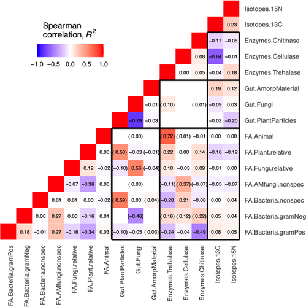

**FIGURE 1**

Spearman rank correlation among 15 trophic niche parameters in Collembola. Red colour represents positive correlations, and blue colour represents negative correlations; to display negative correlations *R*<sup>2</sup> was multiplied by −1. Correlations based on <6 species were excluded, and correlations based on 6–9 species are given in brackets; in other cases, *n* = 10–88 (Table S5). Correlations among parameters derived from different methods are framed within black rectangles

The Δ<sup>13</sup>C values negatively correlated with cellulase activity (*R*<sup>2</sup> = 0.64), chitinase activity (*R*<sup>2</sup> = 0.17) and proportion of plant-synthesised FAs (*R*<sup>2</sup> = 0.16). The Δ<sup>15</sup>N values negatively correlated with proportion of plant particles in gut (*R*<sup>2</sup> = 0.20) and in trend with plant-synthesised FAs (*R*<sup>2</sup> = 0.12), but positively with trehalase activity (*R*<sup>2</sup> = 0.18).

### 3.2 Multidimensional trophic niches of Collembola species

Principal component analysis revealed trophic niche differentiation among the six selected species that had data across seven trophic niche parameters (Figure 2). The strongest distinction in multidimensional trophic niche space was observed between *Orchesella flavescens* (surface-dwelling species of Entomobryidae) and *Protaphorura* (soil-dwelling genus of Onychiuridae). The former species was associated with high proportions of plant-synthesised FAs and plant particles in the gut, and the latter with high proportions of fungi-synthesised FAs and fungi in the gut (PC1 and PC2). *Tomocerus minor* (Tomoceridae) was associated with plant and non-specific bacteria parameters (PC2) but also with fungi and amorphous material in the gut (PC3). *Lepidocyrtus lignorum* (litter-dwelling species of Entomobryidae) was related to fungi in the gut (PC1) and to gram-positive bacteria FAs (PC3). *Parisotoma notabilis* (litter-dwelling species of Isotomidae) and *Onychiurus* (soil-dwelling genus of Onychiuridae) were associated mainly with gram-positive bacteria FAs and amorphous material in the gut.

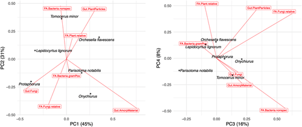

**FIGURE 2**

First four principal components based on seven selected trophic niche parameters of six common Collembola species. Species are shown with grey dots; trophic parameters are shown with red vectors

### 3.3 Taxonomic and life-form effects on trophic niche parameters of Collembola

Taxonomic affiliation best explained stable isotope Δ<sup>13</sup>C and Δ<sup>15</sup>N, and also explained part of the variation in gram-positive and non-specific bacterial FA parameters, proportion of plant and fungi in the gut, and trehalase activity (all *R*<sup>2</sup> ≥ 0.24, *p* < 0.05 except for trehalase; Figure 3). Cellulase activity and proportion of amorphous material in gut were poorly related to the taxonomic affiliation (*R*<sup>2</sup> = 0.03).

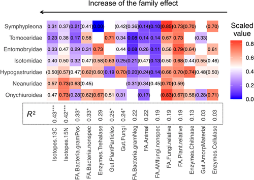

**FIGURE 3**

Median values of trophic niche parameters in Collembola taxonomic groups. All parameters were scaled between 0 (minimum, intense blue) and 1 (maximum, intense red). Parameter values based on <3 species were excluded; values based on 3–5 species are given in brackets; in other cases, *n* = 6–20. Numbers next to parameters indicate *R*<sup>2</sup> explained by taxonomic affiliation; ****p* < 0.001, ***p* < 0.01, **p* < 0.05. Taxonomic groups are sorted according to the orders; parameters are sorted according to the *R*<sup>2</sup> values

Analysed together, the seven Collembola taxonomic groups differed in their trophic niches (Figure 4). Symphypleona had high proportions of FAs synthesised by gram-negative bacteria (PC4) and fungi (PC2), high chitinase and cellulase activities (PC1) but very low trehalase activity (PC2). Tomoceridae were characterised by high proportions of plant particles in the gut (PC1) and low Δ<sup>13</sup>C and Δ<sup>15</sup>N values (PC1, PC2). Entomobryidae had the highest trehalase activity (PC2) but low values of bacteria-related parameters (PC1). By contrast, Isotomidae had lower values of fungi-related parameters (PC2, PC3, PC4). A further separation of Isotomidae into epedaphic and (hemi)edaphic life-forms indicated that epedaphic Isotomidae had lower Δ<sup>13</sup>C values (scaled value of 0.35) than edaphic ones (0.49), a lower proportion of plants (epedaphic: 0.55; edaphic: 0.72) but a higher proportion of fungi in the gut (epedaphic: 0.42; edaphic: 0.20). Hypogastruridae had a remarkably high proportion of fungi in the gut and high chitinase activity, but a low proportion of plant particles in the gut (PC3). Neanuridae had the highest Δ<sup>13</sup>C and Δ<sup>15</sup>N values and proportions of FAs synthesised by gram-positive bacteria and arbuscular-mycorrhizal fungi (PC1). Onychiuroidea had high Δ<sup>15</sup>N values, high proportions of FAs synthesised by non-specific bacteria and fungi, and high cellulase activity (PC4).

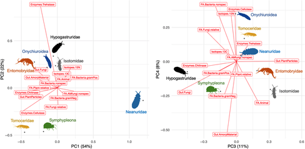

**FIGURE 4**

First four principal components based on median values of the 15 trophic niche parameters of Collembola taxonomic groups. Collembola groups are shown with dots and silhouettes in different colours; trophic parameters are shown with red vectors. Silhouettes were taken from http://phylopic.org, credit goes to Birgit Lang and Kamil S. Jaron

Life-form best explained chitinase activity, but the effect was not significant due to a low number of replicates. Life-form also well explained Δ<sup>15</sup>N values and proportion of FA synthesised by gram-negative bacteria (both *R*<sup>2</sup> ≥ 0.25; Figure 5). Most of the other parameters were moderately or not at all related to life-form.

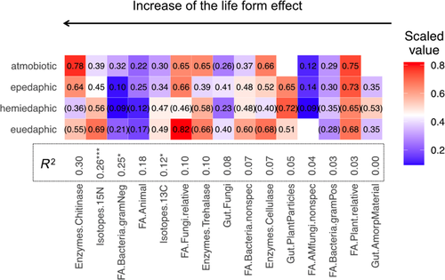

**FIGURE 5**

Median values of trophic niche parameters in Collembola life-forms. All parameters were scaled between 0 (minimum) and 1 (maximum). Parameter values based on <3 species were removed, values based on 3–5 species are given in brackets; in other cases, *n* = 6–36. Numbers next to parameters show *R*<sup>2</sup> explained by life-form; ****p* < 0.001, ***p* < 0.01, **p* < 0.05. Life-forms are sorted according to the species vertical stratification along the soil profile; parameters are sorted according to the *R*<sup>2</sup> values

Atmobiotic species had high average activity of all digestive enzymes and a high proportion of FAs synthesised by gram-negative bacteria and plants. Epedaphic species had in general intermediate values for all parameters, but high proportions of fungi in the gut and high proportions of animal-synthesised FAs. Hemiedaphic species had high Δ<sup>13</sup>C values and proportion of FAs synthesised by gram-positive bacteria, but low activity of chitinase and cellulase. Euedaphic species had the highest Δ<sup>15</sup>N values, high trehalase activity, high proportions of FAs synthesised by fungi and non-specific bacteria.

## 4 DISCUSSION

Different dietary methods track different processes of animal feeding at different resolution and time scales, together offering the possibility to describe multidimensional trophic niches. However, studies quantitatively comparing different methods are scarce, and usually involve two methods only (Nielsen et al., 2018). Here, we compared 15 trophic niche parameters derived from four methods using Collembola as a model group of diverse invertebrates with cryptic feeding habits. First, we showed that most of the trophic niche parameters are weakly correlated, suggesting complementarity rather than redundancy of different methods. However, correlations across methods were found for parameters related to the feeding on plant material and fungi, supporting our hypothesis that the linkage among different feeding processes depends on the resource type. Second, we described multidimensional trophic niches of Collembola, outlining trophic niche parameters that vary with taxonomic groups and life-forms. Partly in accordance with our hypotheses, we found a strong effect of taxonomic affiliation on Δ<sup>15</sup>N values but not animal-synthesised FAs, and an effect of life-form on Δ<sup>15</sup>N values but not the proportion of amorphous material in gut. Nevertheless, several other trophic niche parameters were related to taxonomic affiliation and life-form, together drawing a complex picture of trophic niche differentiation in Collembola.

### 4.1 The added value of method combination

We found weak correlations among trophic niche parameters derived from different methods in 70% of the performed tests, supporting the earlier view that outcomes provided by different methods only in part overlap (Nielsen et al., 2018). Weak correlations may in part be due to technical biases and discrepancies among methods, but are likely majorly explained by their distinctive characterisations of different feeding processes (Table 1), and taken together inform on more trophic niche dimensions (e.g. see Hambäck et al., 2016). Our study demonstrated various types of interactions among the methods and parameters, including confirmation, contradictions, complementarity and clarification. For instance, supporting our first scenario, proportion of plant and fungal particles in gut correlated with retention of plant and fungal FAs, respectively. Visual gut content analysis and FA analysis confirm each other in detection of herbivory and fungivory in Collembola; applying one of the methods may sufficiently trace these feeding strategies. Visual gut content analysis detects ingested food particles and the FA method traces assimilated compounds, implying that in these two food categories, Collembola digest mostly the same material they ingest and the feeding processes are aligned. Furthermore, Δ<sup>15</sup>N and Δ<sup>13</sup>C values were negatively correlated with several plant-related parameters provided by the other methods, confirming (a) that high Δ<sup>15</sup>N values reflect high trophic level as evident from fewer plant particles in the gut and (b) that high Δ<sup>13</sup>C values imply feeding on microbially decomposed organic matter but not freshly fixed plant carbon, thus having a lower need for cellulase (Potapov, Tiunov, & Scheu, 2019; Potapov, Tiunov, Scheu, et al., 2019).

By contrast, digestive enzyme and FA analyses yielded contradictory results in fungi- as well as plant-related parameters. We expected positive correlations between chitinase activity (allowing to degrade chitin in fungal cell walls) and fungal FA proportions, or between cellulase activity (allowing to degrade cellulose in plant and algae cell walls) and plant FA proportions. However, neither was the case. Instead, we found that proportions of fungi in gut and plant- and fungi-synthesised FAs were positively correlated with trehalase activity. Despite more data are needed to verify these correlations, the results may be explained by biological reasons: Trehalose is the storage component of fungal, lichen and plant cells, and these correlations suggest that Collembola get energy and nutrients from storage, rather than structural polysaccharides when feed on plant material and fungi. This means that in relation to the foraging behaviour, fungivorous and herbivorous Collembola are more likely browsers rather than grazers (Siepel & de Ruiter-Dijkman, 1993) and should be specialised in using living or freshly dead material with a high content of storage polysaccharides, and thus be involved in the first stages of decomposition.

We avoided to further discuss correlations since many of them were based only on few data points. In summary, our results showed that FA and visual gut content analyses are congruent in detection of herbivory and fungivory, reflecting that ingestion and retention of these resources are correlated. This pattern is likely to hold in herbivores and fungivores across ecosystems, which could be tested in future studies. Digestive enzyme analysis provided several insights in foraging behaviour and animal–microbial interactions. Although relatively laborious, digestive enzyme analysis could be a powerful tool to reveal cryptic feeding processes in basal consumers if combined with other methods, such as gut content and FA analyses. Finally, stable isotope analysis revealed only rough dietary information (e.g. plant vs. microbial feeding) and trophic levels (e.g. predators, herbivores, decomposers) in the food web; however, other methods could help with interpretation of isotopic data. Our study demonstrated that the multiple methods together depict a more comprehensive picture of the multidimensional trophic niche for the species living in cryptic environments.

### 4.2 Taxonomic and life-form effects on trophic niche parameters

We further explored how the trophic niche parameters vary across different Collembola taxa and life-forms. Family identity explained variation in 6 out of the 15 trophic niche parameters, suggesting that some but not all trophic niche dimensions in Collembola are phylogenetically structured (Potapov et al., 2016). In line with our hypothesis, Δ<sup>15</sup>N values (a parameter detecting predation and algivory) were strongly related to family identity. However, we also found effects of family identity on Δ<sup>13</sup>C values and bacteria-related FA parameters. These parameters are related to biochemical processes in assimilation and thus may in part be constrained by physiology of phylogenetically related species (Chen et al., 2017). By contrast, cellulase activity was not related to taxonomic affiliation, suggesting that the ability of cellulose degradation in Collembola might be evolutionarily labile. Phylogenetic signal in other trophic niche parameters is likely ubiquitous across consumers, but this has rarely been tested in a comprehensive way (see predator–prey mass ratios in Naisbit et al., 2011). A recent study showed that Δ<sup>13</sup>C and Δ<sup>15</sup>N values are related to taxonomic position across soil invertebrates (Potapov, Scheu, & Tiunov, 2019), but studies exploring other trophic niche dimensions are missing. Furthermore, studies on the trophic niche parameters across ecosystems could greatly improve our understanding of eco-evolutionary patterns observed in the animal kingdom (Potapov, Brose, et al., 2019).

Life-form, usually inferred from morphological features of Collembola and used as a proxy for the microhabitat specialisation, only explained variation in three parameters with relatively low *R*<sup>2</sup> values. Most trophic niche parameters were poorly related to life-form. This suggests that various feeding strategies may be used by species living in the same microenvironments, although a part of these weak correlations could also result from a low indicative power of life-forms to the actual microhabitat species live in. Nevertheless, we found higher values of stable isotopes Δ<sup>15</sup>N and Δ<sup>13</sup>C in (hemi)edaphic species, suggesting that species with certain morphological features adapting to soil and litter microhabitats likely have developed feeding strategies that mainly rely on microbially decomposed organic matter and less on plant materials. By contrast, higher chitinase activity in atmobiotic and epedaphic Collembola suggests that they are capable to digest fungal cell walls. Interestingly, atmobiotic species, which mainly inhabit macrophytes (e.g. grasses, bushes, trunks and branches of trees), had higher proportions of gram-negative bacteria FAs, as compared to epedaphic species living in the upper layer of litter. Bacterial communities in these two microhabitats clearly differ from each other. As Collembola are known to consume gram-negative bacteria such as cyanobacteria (Buse et al., 2013; Hao et al., 2020), the atmobiotic species might feed on corticolous cyanobacteria and lichens associated with tree bark (Singh et al., 2017). Furthermore, even within the Isotomidae family, trophic niche parameters differed between epedaphic and (hemi)edaphic species, pointing to environmental determinants of trophic niches in soil animals (Ponge, 2000; Potapov, Tiunov, & Scheu, 2019). Specialisation on a certain microhabitat is expected to be related to trophic specialisation in environments where resources are spatially structured. Despite we did not observe this pattern for most of trophic niche parameters in soil Collembola, it could be observed in other spatially structured ecosystems such as coral reefs (Bellwood et al., 2006). An emerging question here is whether spatial-trophic differentiation is systematically observed for certain resources or trophic niche parameters across ecosystem types.

### 4.3 Multidimensional trophic niches of Collembola and beyond

Using Collembola as an example, this section can serve as a practical illustration for the multidimensional niche approach in animals with cryptic feeding habits as we will further discuss in the last paragraphs. In the following paragraphs, we demonstrate the multidimensional trophic niche of several exemplary Collembola taxa. Such information is derived from combinations of literature review and the multiple trophic parameters of the study.

The order Symphypleona (here representing a conglomerate of several surface-dwelling Collembola families) have high proportions of fungal FAs, high chitinase activity in fungal cell wall degradation and a high proportion of FAs synthesised by gram-negative bacteria. Lichens are comprised of fungi and microalgae or cyanobacteria. Cyanobacteria are gram-negative bacteria able to synthesise hydroxylated FAs (Dembitsky et al., 2001; Gugger, 2002). Together with the findings of low Δ<sup>15</sup>N values in algivores (Potapov et al., 2018), algae and lichen grazing, or a combination of fungivory and herbivory, may be widespread among Symphypleona.

Tomoceridae have a relatively well-defined trophic niche; the combination of parameters points to consumption of plant material with the help of bacteria. They have high proportion of plant particles in the gut among all other Collembola and a relatively high proportion of plant-synthesised FAs. In addition, they have a high proportion of non-specific bacteria FAs, suggesting that they may graze on freshly fallen litter and assimilate it with the help of bacterial symbionts. Clarification of their trophic niche could be advanced with enzyme analysis. The only species *Tomocerus minor* in our database has the highest cellulase activity among all records, confirming its grazing on fresh plant litter.

Entomobryidae include many species that morphologically resemble Tomoceridae; however, these two families differed in a number of trophic niche parameters. Entomobryidae have more fungi in the gut, remarkably high trehalase activity, but a lower proportion of non-specific bacteria FAs. Overall, these differences suggest that Entomobryidae are likely browsers, rather than grazers. *Lepidocyrtus lignorum* is a good illustration—this species prefers fungi (Figure 2), having high trehalase but low cellulase and limited chitinase activity (Table S2).

Isotomidae have lower values of fungi-related parameters and lower enzymatic activity than the previous two families. Isotomidae also have high Δ<sup>13</sup>C values, pointing to consumption of organic material in advanced stages of decomposition (Potapov, Tiunov, & Scheu, 2019), potentially also including invertebrate faeces. All these features are the most expressed in hemiedaphic and euedaphic species that inhabit decomposing litter and soil (e.g. *Parisotoma notabilis*; Figure 2). It is likely that (hemi)edaphic Isotomidae species rely more on bacteria via using the ‘external rumen’ feeding strategy. These species are usually small and their gut often contains humus (i.e. soil and faecal material; Ponge, 2000; Poole, 1959). Interestingly, hemiedaphic and euedaphic Isotomidae such as species of the genera *Isotomiella*, *Folsomia*, *Parisotoma, Folsomides*, dominate in Collembola communities in many ecosystems (Potapov, 2001). Thus, bacterial feeding may be more common in Collembola than it is assumed in traditional soil food web models (e.g. de Vries et al., 2013; Hunt et al., 1987).

Hypogastruridae have the highest proportion of fungi and the lowest proportion of plants in the gut across all other Collembola and low activity of cellulase, suggesting that they feed selectively on micro-organisms but not on plant material. Species of this family can live and feed on fungi (Sawahata et al., 2001), and have relatively high proportions of fungi-synthesised FAs (Ferlian et al., 2015). Taken together, Hypogastruridae are fungivores, or, more broadly, microbivores.

Neanuridae have no molar plate and are thus unable to chew the food. This family is long recognised to have a distinct trophic niche from other Collembola families (Berg et al., 2004; Chahartaghi et al., 2005; Singh, 1969). However, their exact food objects remain enigmatic. Neanuridae are likely to feed by sucking up the content of fungal hyphae (Poole, 1959; Singh, 1969). They have an outstandingly high trophic level, as indicated by stable isotope analysis, suggesting that Neanuridae may feed on other animals, such as nematodes (Chahartaghi et al., 2005). Neanuridae can successfully breed on slime moulds (protists with mycelial stage; Hoskins et al., 2015). Slime moulds are abundant in various ecosystems (Swanson et al., 1999) and tend to live in rotten wood, as do Neanuridae. Slime moulds, therefore, potentially serve as food for some species of this family in natural environments. In our study, the Neanuridae have high average values of bacteria- and fungi-related parameters, high Δ<sup>13</sup>C and Δ<sup>15</sup>N values, but very low plant supplementation, supporting the above-mentioned hypotheses. Interestingly, Neanuridae also have a high proportion of FAs synthesised by arbuscular-mycorrhizal fungi; however, the same biomarkers can also be synthesised by bacteria. Neanuridae, as high-level consumers among Collembola, feed on various groups of microfauna and micro-organisms and receive energy from both bacterial and fungal origins.

Onychiuroidea are soil-adapted Collembola without eyes, pigment and furca (jumping organ). They are associated with plant roots, presumably by feeding on root tips or mycorrhizae (Endlweber et al., 2009; Fujii et al., 2016; Potapov et al., 2016). They have intermediate proportions of plant and fungal particles in their gut in comparison to other Collembola. However, they have high proportions of FAs synthesised by fungi and non-specific bacteria and a high cellulase activity. Potentially, Onychiuroidea may feed on both roots and microbes residing in soil. However, the small-sized Tullbergiidae, which were analysed with Onychiuridae in our study, may rely less on root-derived resources (Li et al., 2020). Food resources of different groups and species within this superfamily should be explored in further studies.

The meta-analysis approach used in our study relied on rather heterogeneous data compiled from multiple empirical studies. While our results may not always be applicable to describe realised niches of coexisting species in local communities, where interspecific interactions may shift instant niches of species, presumably we have approached ‘fundamental’ multidimensional trophic niches of Collembola across different habitats and seasons. Trophic parameters measured simultaneously among species in one community, although likely to reflect realised niches, provide only a snapshot of multidimensional trophic niches, especially if methods such as visual or DNA gut content analyses are applied. Application of multiple methods to the same species across different ecosystems and seasons is needed to verify correlations among trophic parameters recorded in our study and precisely describe fundamental trophic niches of species.

To conclude, using Collembola as an example, our study is the first cross-method compilation of trophic niche parameters that clearly shows advantages of the multidimensional trophic niche approach. We suggest that our study complements and expands stoichiometric (González et al., 2017) and nutritional (Machovsky-Capuska et al., 2016) multidimensional niche concepts, specifically taking food choices and ingestion rates into consideration and thus focusing on the ecosystem impact of consumers and resource partitioning in communities. Generally, the concept may be applied to any consumer and ecosystem; however, we suggest that it would be most valuable for (a) omnivorous and detritivorous animals that feed on a variety of food objects of different quality and (b) cryptic ecosystems where trophic interactions are hard to observe directly. Knowledge about such consumers and ecosystems is especially scarce; however, some research has shed light on the trophic niche differentiation in, for example, protists and copepods in benthic marine food webs (Haynert et al., 2020; Mascart et al., 2018), or trophic interactions of saproxylic beetles in deadwood communities (Wende et al., 2017). With a combination of methods, we will be finally able to open the ‘black box’ of cryptic food webs, as was coined by Odum (1971).

## ACKNOWLEDGEMENTS

This study was funded by the Russian Science Foundation (project 19-74-00154) to A.M.P. Research visit of T.-W.C. was supported by the Czech Academy of Sciences with the MSM project for research and mobility of starting researchers (MSM200962001). M.M.P. was supported by the German Research Foundation (DFG, MA 7145/1-1). Joint discussions among T.-W.C., V.S., M.M.P. and A.M.P. were supported within the CAS-DAAD mobility project (DAAD-19-10/57448388) co-funded by Czech Academy of Sciences (CAS) and German Academic Exchange Service (DAAD, Deutscher Akademischer Austauschdienst). We are grateful to the editor and two anonymous reviewers who suggested valuable conceptual improvements of the manuscript.

## AUTHORS' CONTRIBUTIONS

A.M.P. and T.-W.C. developed the idea and study design; S.S., V.S., M.M.P. and A.M.P., respectively, compiled the data on gut content, digestive enzyme, fatty acid and stable isotope analyses; A.M.P. and T.-W.C. performed the data analysis and drafted the manuscript. All authors critically revised the analysis and manuscript.

## REFERENCES

[figure not shown]

### Details

© 2021 The Authors. *Journal of Animal Ecology* published by John Wiley & Sons Ltd on behalf of British Ecological Society

This is an open access article under the terms of the [Creative Commons Attribution-NonCommercial-NoDerivs](http://creativecommons.org/licenses/by-nc-nd/4.0/) License, which permits use and distribution in any medium, provided the original work is properly cited, the use is non-commercial and no modifications or adaptations are made.

[figure not shown]

### Research funding

- Russian Science Foundation. Grant Number: 19-74-00154
- Deutscher Akademischer Austauschdienst. Grant Number: 57448388
- Deutsche Forschungsgemeinschaft. Grant Number: MA 7145/1-1
- Akademie Věd České Republiky. Grant Numbers: DAAD-19-10, MSM200962001

### Keywords

- biomarkers
- [diet tracing](https://besjournals.onlinelibrary.wiley.com/action/doSearch?field1=Keyword&text1=diet%20tracing)
- [food webs](https://besjournals.onlinelibrary.wiley.com/action/doSearch?field1=Keyword&text1=food%20webs)
- [meta-analysis](https://besjournals.onlinelibrary.wiley.com/action/doSearch?field1=Keyword&text1=meta%E2%80%90analysis)
- [method comparison](https://besjournals.onlinelibrary.wiley.com/action/doSearch?field1=Keyword&text1=method%20comparison)
- springtails
- [trophic interactions](https://besjournals.onlinelibrary.wiley.com/action/doSearch?field1=Keyword&text1=trophic%20interactions)

### Publication History

- Version of Record online: 31 May 2021
- Accepted manuscript online: 29 April 2021
- Manuscript accepted: 22 April 2021
- Manuscript received: 13 July 2020